# Exploratory Data Analysis on the **automobile** Dataset

#### Which vehicle manufacturer has the most car models in the dataset

```python
# 1) Count models per manufacturer
manufacturer_counts = (
    automobiles_df
      .groupby('make')
      .size()
      .reset_index(name='count')
      .sort_values('count', ascending=False)
)

print(manufacturer_counts)

# 2) Extract the top row
top = manufacturer_counts.iloc[0]
print(f"\nThe manufacturer with the most car models is "
      f"{top['make']} with {top['count']} models in the dataset.")
```

```
             make  count
18         toyota     32
12         nissan     18
11     mitsubishi     13
5           honda     13
8           mazda     13
19     volkswagen     12
17         subaru     12
20          volvo     11
13         peugot     11
4           dodge      9
9   mercedes-benz      8
2             bmw      8
14       plymouth      7
1            audi      6
16           saab      6
15        porsche      4
0     alfa-romero      3
3       chevrolet      3
7          jaguar      3
6           isuzu      2
10        mercury      1

The manufacturer with the most car models is toyota with 32 models in the dataset.
```

```
   price  city-mpg  highway-mpg  avg-mpg
0  13495        21           27     24.0
1  16500        21           27     24.0
2  16500        19           26     22.5
3  13950        24           30     27.0
4  17450        18           22     20.0
```

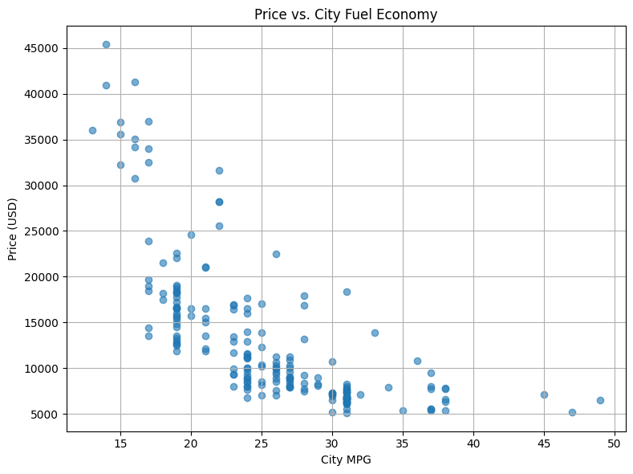

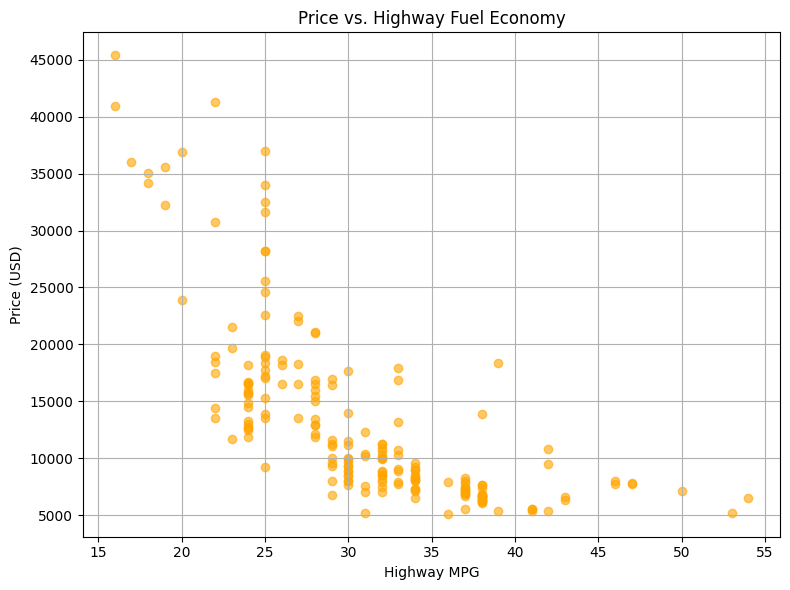

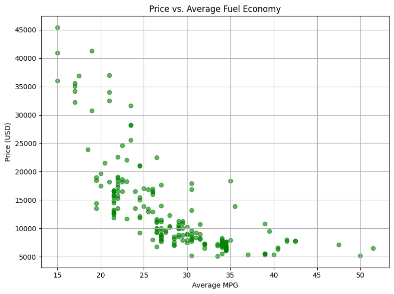

```python
# 1) Create a lightweight DataFrame “view”
price_mpg = automobiles_df[['price','city-mpg','highway-mpg']].copy()
# add average MPG if you like
price_mpg['avg-mpg'] = price_mpg[['city-mpg','highway-mpg']].mean(axis=1)

# quick peek
print(price_mpg.head())

# 2) Scatter: Price vs. City MPG
plt.figure(figsize=(8,6))
plt.scatter(price_mpg['city-mpg'], price_mpg['price'], alpha=0.6)
plt.xlabel('City MPG')
plt.ylabel('Price (USD)')
plt.title('Price vs. City Fuel Economy')
plt.grid(True)
plt.tight_layout()
plt.show()

# 3) Scatter: Price vs. Highway MPG
plt.figure(figsize=(8,6))
plt.scatter(price_mpg['highway-mpg'], price_mpg['price'], alpha=0.6, color='orange')
plt.xlabel('Highway MPG')
plt.ylabel('Price (USD)')
plt.title('Price vs. Highway Fuel Economy')
plt.grid(True)
plt.tight_layout()
plt.show()

# 4) (Optional) Price vs. Average MPG
plt.figure(figsize=(8,6))
plt.scatter(price_mpg['avg-mpg'], price_mpg['price'], alpha=0.6, color='green')
plt.xlabel('Average MPG')
plt.ylabel('Price (USD)')
plt.title('Price vs. Average Fuel Economy')
plt.grid(True)
plt.tight_layout()
plt.show()
```

1. **Inverse relationship**: Fuel efficiency (whether city, highway, or average) is negatively correlated with price in this dataset.
2. **Cluster structure**:
   - High-price, low-mpg cluster (luxury/performance models).
   - Low-price, high-mpg cluster (economy models).
3. **Outliers & variance**: A few makes (e.g. some Porsches) manage moderate mpg at high prices, and mid-priced cars show a wider mpg spread—so mpg explains much but not all of price variation.
4. **Business insight**: In this sample, buyers pay a premium for power, luxury, or brand over fuel economy; conversely, the most fuel-efficient cars tend to be budget-priced models.

**This report was written by:** *Lungelo Mkhungo*